# Wilcoxon / Mann-Whitney Test in R

[Nathaniel E. Helwig](http://stat.umn.edu/~helwig) Department of Psychology & School of Statistics University of Minnesota

Copyright © February 15, 2026

# 1 Two-Sample Location Problem

## 1.1 Overview

For the *two-sample* location problem, we have $N = m + n$ observations

- $X_1, \ldots, X_m$ are iid random sample from $F_X$
- $Y_1, \ldots, Y_n$ are iid random sample from $F_Y$

Note that the observations are independent within and between groups.

## 1.2 Location-Shift Model

The *location-shift* model assumes that

- $F_X(z - \delta) = F_Y(z)$ where $\delta = \mu_X - \mu_Y$ is the treatment effect
- $X_i = \mu_X + \epsilon_i$ and $Y_j = \mu_Y + e_j$

Note that the error terms $\epsilon_i$ and $e_j$ are assumed to be iid with mean zero.

## 1.3 Null and Alternative Hypotheses

The null hypothesis about $\delta$ (treatment effect) is
$$H_{0}: \delta = 0$$
and we could have one of three alternative hypotheses:

- $H_{1}: \delta > 0$ Greater Than
- $H_{1}: \delta < 0$ Less Than
- $H_{1}: \delta \neq 0$ Two-Sided

# 2 Methodological Details

## 2.1 Wilcoxon Rank Sum Statistic

Let $Z_k$ denote the $k$-th element of the combined sample $(X_1, \ldots, X_m, Y_1, \ldots, Y_n)$

Let $R_k$ denote the rank of $Z_k$ for $k = 1, \ldots, N$

Defining the indicator variable
$$\psi_k = \left\{\begin{array}{ll} 1 & \mbox{if } Z_k \mbox{ is from
} F_X \ \longleftrightarrow \ 1 \leq k \leq m \\ 0 & \mbox{if }
Z_k \mbox{ is from } F_Y \ \longleftrightarrow \ m+1 \leq k \leq N
\end{array}\right.$$
the Wilcoxon rank sum test statistic $W$ is defined as
$$W = \sum_{k=1}^N R_k \psi_k$$
which sums the (combined) ranks corresponding to the $X$ observations.

## 2.2 Mann-Whitney $U$ Statistic

Defining the indicator function
$$\phi(X_i, Y_j) =
\left\{
\begin{array}{cl} 1 & \mbox{if } X_i < Y_j \\
0 & \mbox{otherwise}
\end{array}\right.$$
the Mann-Whitney test statistic $U$ is defined as
$$U = \sum_{i=1}^m \sum_{j=1}^n \phi(X_i, Y_j)$$
which counts the number of times $X$ is before $Y$ in combined sample.

It can be shown
$$W' = \frac{N(N+1)}{2} - W = U + \frac{n(n+1)}{2}$$
where $W$ and $U$ are the Wilcoxon and Mann-Whitney test statistics. Note that this implies
$$W = \frac{m (m + 2n + 1)}{2} - U$$
so the $W$ and $U$ statistics have the same distribution up to a location shift.

## 2.3 Null Distribution

Under $H_0$ all ${m + n \choose m}$ arrangements of $X$-ranks occur with equal probability.

- Given $m$ and $n$, calculate $W$ for all ${m + n \choose m}$ possible outcomes
- Each outcome has probability $1/ {m + n \choose m}$ under $H_0$

Suppose we have $m = 2$ observations from $F_X$ and $n = 3$ observations from $F_Y$

There are ${5 \choose 2} = 10$ possible configurations of the $X$ ranks

| X-ranks | $W = \sum_{k=1}^N R_k \psi_k$ | Probability under $H_{0}$ |
| --- | --- | --- |
| 1,2 | 3 | $1/10$ |
| 1,3 | 4 | $1/10$ |
| 1,4 | 5 | $1/10$ |
| 1,5 | 6 | $1/10$ |
| 2,3 | 5 | $1/10$ |
| 2,4 | 6 | $1/10$ |
| 2,5 | 7 | $1/10$ |
| 3,4 | 7 | $1/10$ |
| 3,5 | 8 | $1/10$ |
| 4,5 | 9 | $1/10$ |

## 2.4 Statistical Inference

### 2.4.1 Exact Test

One-Sided Test (Greater Than)

- $H_{0}: \delta = 0$ versus $H_{1}: \delta > 0$
- Reject $H_{0}$ if $W \geq w_{1-\alpha}$ where $P(W>w_{1-\alpha})=\alpha$
- P-Value: $p = \frac{1}{M} \sum_{j=1}^{M} I(W_j \geq W_{\mathrm{obs}})$ where $M = {m+n \choose m}$

One-Sided Test (Less Than)

- $H_{0}: \delta = 0$ versus $H_{1}: \delta < 0$
- Reject $H_{0}$ if $W\leq w_{\alpha}$ where $P(W<w_{\alpha})=\alpha$
- P-Value: $p = \frac{1}{M} \sum_{j=1}^{M} I(W_j \leq W_{\mathrm{obs}})$ where $M = {m+n \choose m}$

Two-Sided Test

- $H_{0}: \delta = 0$ versus $H_{1}: \delta \neq 0$
- Reject $H_{0}$ if $W \leq w_{\alpha/2}$ OR $W\geq w_{1-\alpha/2}$
- P-Value: $p = \frac{1}{M} \sum_{j=1}^{M} I(|W_j| \geq |W_{\mathrm{obs}}|)$ where $M = {m+n \choose m}$

Note: the null distribution is symmetric so $w_{\alpha/2} = m(N+1) - w_{1-\alpha/2}$

### 2.4.2 Large Sample Approximation

Under $H_{0}$, the expected value and variance of $W$ are

- $E(W) = \frac{m(m+n+1)}{2}$
- $V(W) = \frac{mn(m+n+1)}{12}$

We can create a standardized test statistic $W^{*}$ of the form
$$W^{*} = \frac{W-E(W)}{\sqrt{V(W)}}$$
which asymptotically follows a $\mathrm{N}(0,1)$ distribution.

Derivation of Large Sample Approximation:

Note that $W = \sum_{k=1}^N R_k \psi_k = \sum_{i=1}^m S_i$ where $S_i$ is the (combined) rank associated with $X_i$.

- $\bar{W} = W/m$ is the average of the (combined) $X$-ranks
- $\bar{W}$ is sample mean of size $m$ drawn *without* replacement from $\mathbb{W} = \{1, \ldots, N\}$

Using some basic results of finite population theory:

- $E(\bar{W}) = \mu$ where $\mu = \frac{1}{N} \sum_{k=1}^N k = \frac{N+1}{2}$
- $V(\bar{W}) = \sigma^2 \frac{n}{m(N-1)}$ where $\sigma^2 = (\frac{1}{N} \sum_{k=1}^N k^2) - \mu^{2} = \frac{(N-1)(N+1)}{12}$

Putting things together, we have that

- $E(W) = m \mu = \frac{m(N+1)}{2}$
- $V(W) = m^2 \sigma^2 \frac{n}{m(N-1)} = \frac{mn(N+1)}{12}$

### 2.4.3 Handling Ties

If $Z_i = Z_j$ for two observations from combined sample $(X_1, \ldots, X_m, Y_1, \ldots, Y_n)$, then the ranks $R_k$ are not uniquely defined.

$W$ is calculated in the same fashion but using the average ranking procedure.

For inference purposes, note that when $W$ is calculated with average ranks:

- Average ranks with null distribution is approximate level $\alpha$ test
- Can still obtain an exact level $\alpha$ test via conditional distribution
- Need to adjust variance term for large sample approximation

## 2.5 Estimating Location

To estimate the treatment effect $\delta$, first form the $mn$ differences
$$D_{ij} = X_i - Y_j$$
for $i = 1,\ldots,m$ and $j = 1,\ldots,n$.

The *Hodges-Lehman* estimate of $\delta$ corresponding to Wilcoxon’s rank sum test is
$$\hat{\delta} = \mbox{median}(D_{ij}; \ i=1,\ldots,m; j = 1,\ldots,n)$$
which is the median of the differences.

Motivation: make mean of $(X_1 - \hat{\delta}, \ldots, X_m - \hat{\delta}, Y_1, \ldots, Y_n)$ as close as possible to $E(W) = m(m+n+1)/2$.

## 2.6 Confidence Intervals

Define the following terms

- Let $U^{(1)} \leq U^{(2)} \leq \cdots \leq U^{(mn)}$ denote the ordered $D_{ij}$ scores
- $w_{1-\alpha/2}$ is the critical value such that $P(W>w_{1-\alpha/2})=\alpha/2$ under $H_{0}$
- $C_{\alpha/2}=\frac{m(m+2n+1)}{2} + 1 - w_{1-\alpha/2}$ is the transformed critical value

A symmetric $(1-\alpha)100$% confidence interval for $\delta$ is given by

- $\delta_{L} = U^{(C_{\alpha/2})}$
- $\delta_{U} = U^{(mn+1-C_{\alpha/2})}$

An asymmetric $(1-\alpha)100$% upper confidence bound for $\delta$ is

- $\delta_{L} = -\infty$
- $\delta_{U} = U^{(mn+1-C_{\alpha})}$

An asymmetric $(1-\alpha)100$% lower confidence bound for $\delta$ is

- $\delta_{L} = U^{(C_{\alpha})}$
- $\delta_{U} = \infty$

# 3 Example

## 3.1 Data and Problem

### 3.1.1 Overview of Problem

Example 4.2 from *Nonparametric Statistical Methods, 3rd Ed*

Two alcohol treatment programs:

- Control = standard treatment program
- SST = Social Skills Training program

Note: SST is a supplement to standard treatment program

$N = 23$ total patients ($m = 12$ Control and $n = 11$ SST)

Response variable is the post-treatment alcohol intake for each patient group.

### 3.1.2 Data Table

Table 4.2 Alcohol Intake for 1 Year (Centiliter of Pure Alcohol)

| Control $X_i$ | Control ($R_k$) | SST $Y_j$ | SST ($R_k$) |
| --- | --- | --- | --- |
| 1042 | (13) | 874 | (9) |
| 1617 | (23) | 389 | (2) |
| 1180 | (18) | 612 | (4) |
| 973 | (12) | 798 | (7) |
| 1552 | (22) | 1152 | (17) |
| 1251 | (19) | 893 | (10) |
| 1151 | (16) | 541 | (3) |
| 1511 | (21) | 741 | (6) |
| 728 | (5) | 1064 | (14) |
| 1079 | (15) | 862 | (8) |
| 951 | (11) | 213 | (1) |
| 1319 | (20) |  |  |

Source: L. Eriksen, S. Bjornstad, and K. G. Gotestam (1986).

## 3.2 By Hand

### 3.2.1 Rank Sums

| Control $X_i$ | Control ($R_k$) | SST $Y_j$ | SST ($R_k$) |
| --- | --- | --- | --- |
| 1042 | (13) | 874 | (9) |
| 1617 | (23) | 389 | (2) |
| 1180 | (18) | 612 | (4) |
| 973 | (12) | 798 | (7) |
| 1552 | (22) | 1152 | (17) |
| 1251 | (19) | 893 | (10) |
| 1151 | (16) | 541 | (3) |
| 1511 | (21) | 741 | (6) |
| 728 | (5) | 1064 | (14) |
| 1079 | (15) | 862 | (8) |
| 951 | (11) | 213 | (1) |
| 1319 | (20) |  |  |
| $\sum$ | 195 | $\sum$ | 81 |

### 3.2.2 Test Statistic

The observed test statistic is $W = \sum_{k=1}^N R_k \psi_k = 195$

Note that the rank sums satisfy
$$\begin{split}
276 &= 195 + 81 \\
&= \sum_{k=1}^N R_k \psi_k + \sum_{k=1}^N R_k (1-\psi_k) \\
&= \sum_{k=1}^N R_k = \frac{N(N+1)}{2}
\end{split}$$
due to Gauss’s rule, so we could equivalently use $W' = \sum_{k=1}^N R_k (1-\psi_k) = 81$

## 3.3 Using R

### 3.3.1 Input Data

Load Data:

```r
x <- c(1042, 1617, 1180,  973, 1552, 1251, 1151, 1511,  728, 1079,  951, 1319)
y <- c(874,  389,  612,  798, 1152,  893,  541,  741, 1064,  862,  213)
```

### 3.3.2 Wilcoxon’s Rank Sum Test (stats package)

Wilcoxon’s Rank Sum Test using **stats** package:

```r
wilcox.test(x, y, alternative = "greater", conf.int = TRUE)
```

```
##
##  Wilcoxon rank sum exact test
##
## data:  x and y
## W = 117, p-value = 0.0004904
## alternative hypothesis: true location shift is greater than 0
## 95 percent confidence interval:
##  217 Inf
## sample estimates:
## difference in location
##                  435.5
```

Note: R’s `wilcox.test` function reports $W_* = mn - W' + n(n+1)/2$

### 3.3.3 Wilcoxon’s Rank Sum Test (nptest package)

Wilcoxon’s Rank Sum Test using **nptest** package:

```r
library(nptest)
set.seed(1)
mod <- np.loc.test(x, y, alternative = "greater", median.test = TRUE, var.equal = TRUE)
mod
```

```
##
## Nonparametric Location Test (Wilcoxon Rank Sum Test)
## alternative hypothesis: true median of differences is greater than 0
## t = 3.1388,  p-value = 9e-04
## sample estimate:
## median of the differences
##                     435.5
```

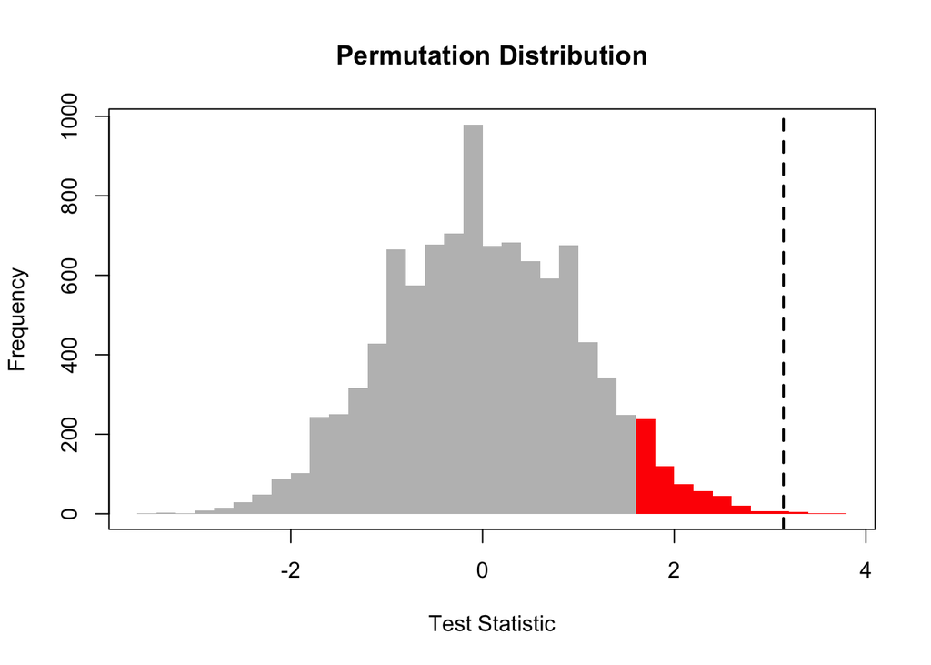

```r
plot(mod)
```

To get the confidence lower bound

```r
m <- length(x)
n <- length(y)
#mod <- np.loc.test(x, y, alternative = "greater",
#                   median.test = TRUE,
#                   var.equal = TRUE,
#                   R = choose(m+n, m))               # exact test
z <- outer(x, y, FUN = "-")                          # difference score
M <- m * n                                           # m * n = 132
U <- sort(c(z))                                      # sorted scores
critval <- quantile(mod$perm.dist, probs = 0.95)     # std crit val
expval <- m * (m + n + 1) / 2                        # expected value (under H0)
varval <- m * n * (m + n + 1) / 12                   # variance (under H0)
critval <- critval * sqrt(varval) + expval           # raw crit val
tcv <- m * (m + 2*n + 1) / 2 - critval               # transformed crit val
c(U[tcv], Inf)                                       # 95% lower bound
```

```
## [1] 232 Inf
```

### 3.3.4 Student’s t test (stats package)

Student’s $t$ test:

```r
t.test(x, y, alternative = "greater")
```

```
##
##  Welch Two Sample t-test
##
## data:  x and y
## t = 3.9747, df = 20.599, p-value = 0.0003559
## alternative hypothesis: true difference in means is greater than 0
## 95 percent confidence interval:
##  258.5566      Inf
## sample estimates:
## mean of x mean of y
## 1196.1667  739.9091
```

### 3.3.5 Student’s t test (nptest package)

Student’s $t$ test:

```r
set.seed(1)
mod <- np.loc.test(x, y, alternative = "greater")
mod
```

```
##
## Nonparametric Location Test (Welch Two Sample t-test)
## alternative hypothesis: true difference of means is greater than 0
## t = 3.9747,  p-value = 6e-04
## sample estimate:
## difference of the means
##                456.2576
```

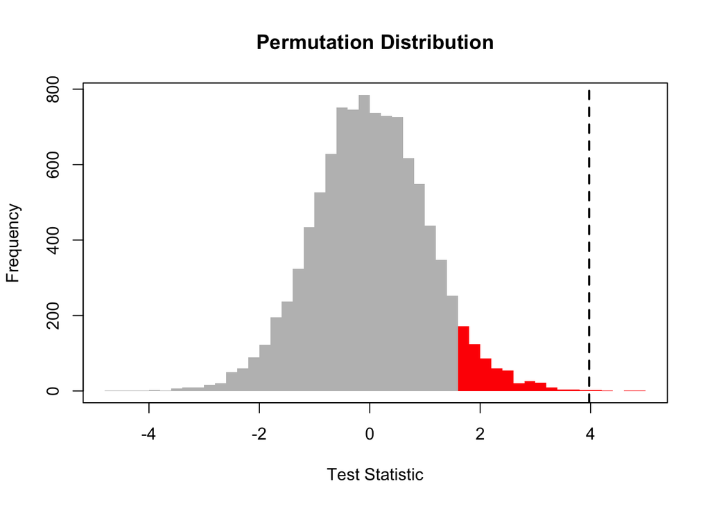

```r
plot(mod)
```